# R Notebook

Load in necessary packages:

```r
library(dplyr)
library(purrr)
library(popbio)
library(devtools)
library(ggplot2)
library(ggpubr)
```

Load, minimally clean our data

```r
setwd("C:/Users/front/Seafile/CloudDocs/Klass/Insect Ecology/BeetleDensity/")
df <- read.csv("counts_master3.csv")
df <- df %>% filter(Replicate != 0) #Pesky extra row in the df, let's delete
df[df==0] <- NA # Values of 0 indicate NA, let's be explicit
df <- df %>% dplyr::mutate(Treatment = factor(Treatment, levels = c("L", "M", "H"))) %>% arrange(Treatment) # Reorder treatment levels hierarchically, for better figures
```

Who counted the most?

```r
counter_ranks <- df %>%
  group_by(Counter) %>%
  dplyr::summarise_at(c("Eggs","Larvae","Pupae","Adult"),sum, na.rm = TRUE) %>%
  ungroup() %>%
  rowwise(Counter) %>%
  mutate(Counter_Total = sum(c_across()))
```

I want to explore cannibalism hypothesis for low survivorship in low density setting. Let’s explore variability in larvae count for the larvae count day. Does low density cause there to be more lifestage overlap, thus more opportunities for cannibalism? Let’s define a function to calculate mean and SD for each group in a dataset.

```r
#+++++++++++++++++++++++++
# Function to calculate the mean and the standard deviation
# for each group
#+++++++++++++++++++++++++
# data : a data frame
# varname : the name of a column containing the variable
#to be summariezed
# groupnames : vector of column names to be used as
# grouping variables
data_summary <- function(data, varname, groupnames){
  require(plyr)
  summary_func <- function(x, col){
    c(mean = mean(x[[col]], na.rm=TRUE),
      sd = sd(x[[col]], na.rm=TRUE))
  }
  data_sum<-ddply(data, groupnames, .fun=summary_func,
                  varname)
  data_sum <- rename(data_sum, c("mean" = varname))
  return(data_sum)
}
```

Let’s track totals of all stages per day, grouped by treatment.

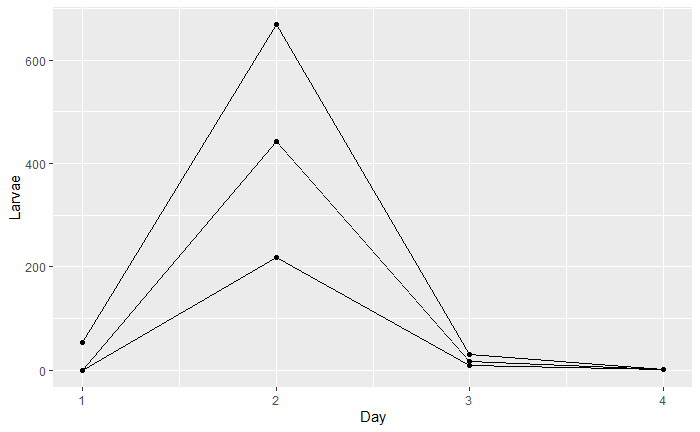

```r
summary_perDay <- df %>%
  group_by(Treatment, Day) %>%
  summarise_at(c("Eggs","Larvae","Pupae","Adult"),sum, na.rm = TRUE)

ggplot(data=summary_perDay, aes(x=Day, y=Larvae, group=Treatment)) +
  geom_line() +
  geom_point()
```

Waht does variability in larvae count look like over time?

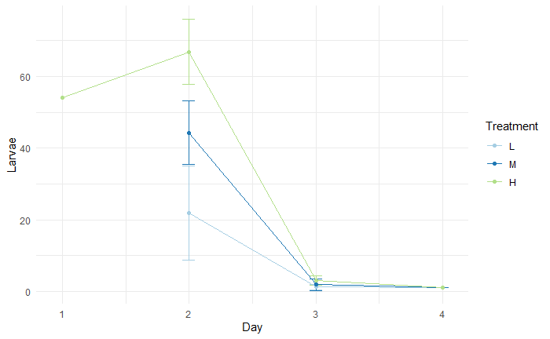

```r
### Larvae
day2 <- df %>% filter(Day == 2)
larvae_df <- data_summary(df, varname = "Larvae", groupnames = c("Treatment", "Day"))
# Standard deviation of the mean
ggplot(larvae_df, aes(x=Day, y=Larvae, group=Treatment, color=Treatment)) +
  geom_errorbar(aes(ymin=Larvae-sd, ymax=Larvae+sd), width=.1) +
  geom_line() + geom_point()+
  scale_color_brewer(palette="Paired")+theme_minimal()
```

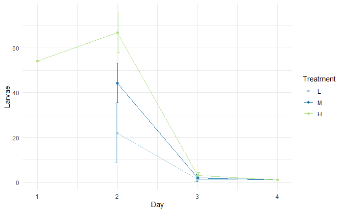

```r
# Use position_dodge to move overlapped errorbars horizontally
ggplot(larvae_df, aes(x=Day, y=Larvae, group=Treatment, color=Treatment)) +
  geom_errorbar(aes(ymin=Larvae-sd, ymax=Larvae+sd), width=.1,
                position=position_dodge(0.05)) +
  geom_line() + geom_point()+
  scale_color_brewer(palette="Paired")+theme_minimal()
```

Seems like high variance for Low treatment. I want to test significance of this. First, we need to check that these data are normally distributed. I’m only aware of Bartless, F-test, Levene to test equality of variance. For all these, you need data to be normally distributed.

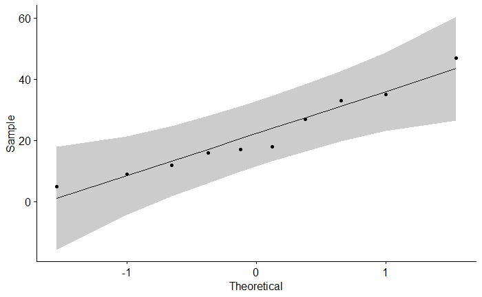

```r
day1.df <- df %>% filter(Day == 1)
day2.df <- df %>% filter(Day == 2)
day3.df <- df %>% filter(Day == 3)
day4.df <- df %>% filter(Day == 4)

# Check assumptions to perform F-test comparing variances
L.df <- df %>% filter(Treatment == "L") %>% filter(Day == 2)
ggqqplot(L.df$Larvae)
```

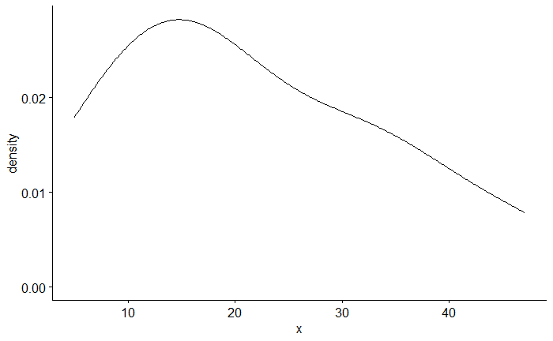

```r
ggdensity(L.df$Larvae) # Weirdly
```

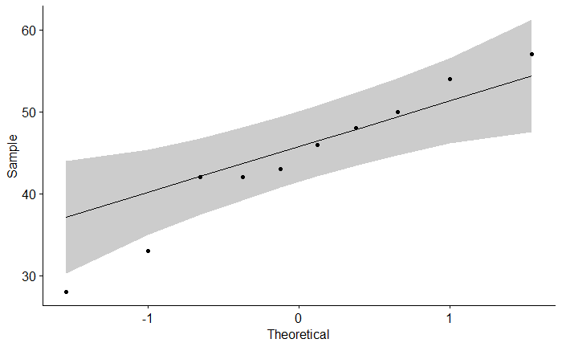

```r
M.df <- df %>% filter(Treatment == "M") %>% filter(Day == 2)
ggqqplot(M.df$Larvae)
```

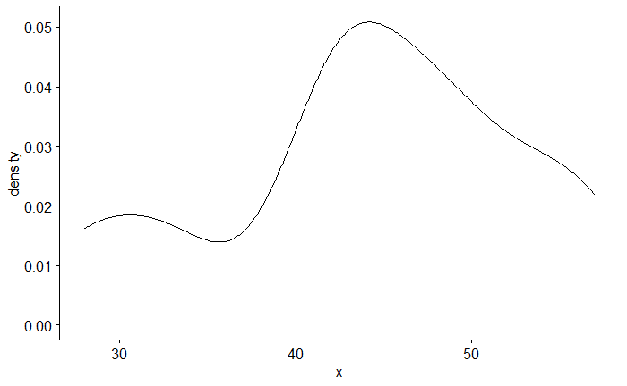

```r
ggdensity(M.df$Larvae) # @ peaked...
```

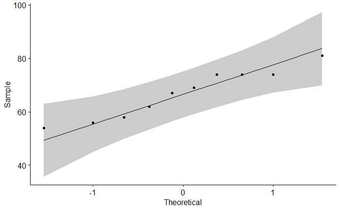

```r
H.df <- df %>% filter(Treatment == "H") %>% filter(Day == 2) # OK this one looks pretty bad.
ggqqplot(H.df$Larvae)
```

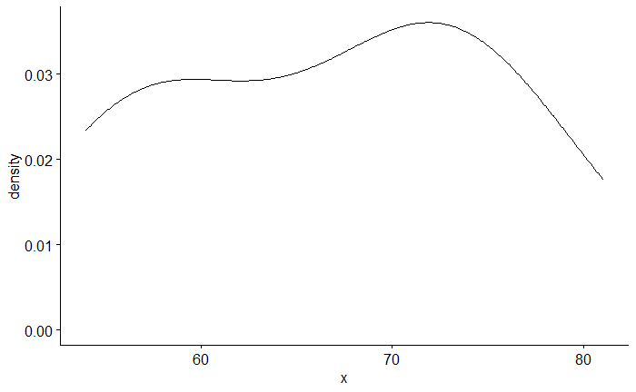

```r
ggdensity(H.df$Larvae) # It is actuall 2-peaked!
```

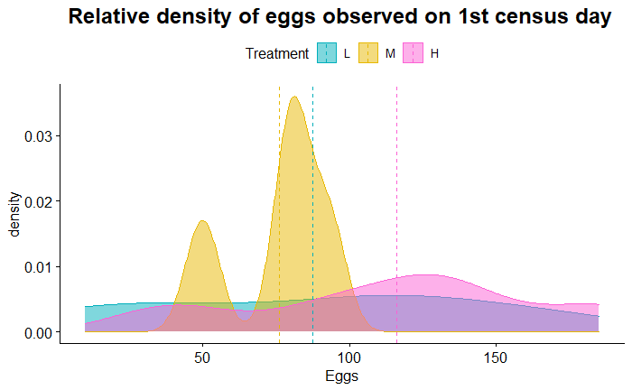

```r
ggdensity(data = day1.df, x = "Eggs", add = "mean", combine = TRUE,title = "Relative density of eggs observed on 1st census day",
          color = "Treatment", fill = "Treatment", palette = c("#00AFBB", "#E7B800", "#FC61D5"), ggtheme = theme_pubr()) +
  theme(plot.title = element_text(face = "bold", size = 18, hjust = .45),
        )
```

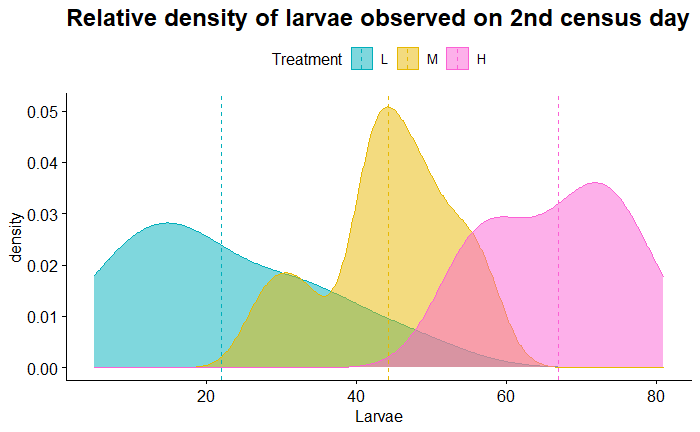

```r
ggdensity(data = day2.df, x = "Larvae", add = "mean", combine = TRUE,title = "Relative density of larvae observed on 2nd census day",
          color = "Treatment", fill = "Treatment", palette = c("#00AFBB", "#E7B800", "#FC61D5"), ggtheme = theme_pubr()) +
  theme(plot.title = element_text(face = "bold", size = 18, hjust = .45),
        )
```

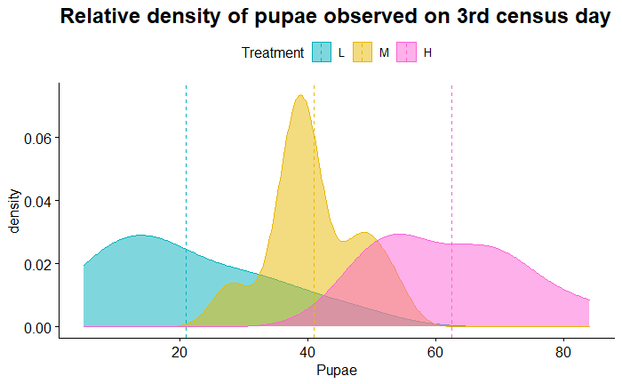

```r
ggdensity(data = day3.df, x = "Pupae", add = "mean", combine = TRUE,title = "Relative density of pupae observed on 3rd census day",
          color = "Treatment", fill = "Treatment", palette = c("#00AFBB", "#E7B800", "#FC61D5"), ggtheme = theme_pubr()) +
  theme(plot.title = element_text(face = "bold", size = 18, hjust = .45),
        )
```

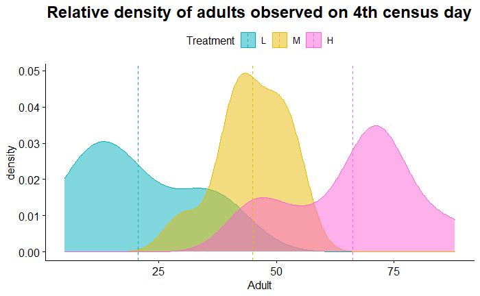

```r
ggdensity(data = day4.df, x = "Adult", add = "mean", combine = TRUE,title = "Relative density of adults observed on 4th census day",
          color = "Treatment", fill = "Treatment", palette = c("#00AFBB", "#E7B800", "#FC61D5"), ggtheme = theme_pubr()) +
  theme(plot.title = element_text(face = "bold", size = 18, hjust = .45),
        )
```

```r
  # In general I think it's close enough, let's go ahead and compare those variances. EDIT-- not even close to normal, don't do this
df.LM <- df %>% filter(Day == 2) %>% filter(Treatment != "H")
var.LM.larvae <- var.test(Larvae ~ Treatment, data = df.LM)

df.LH <- df %>% filter(Day == 2) %>% filter(Treatment != "M")
var.LH.larvae <- var.test(Larvae ~ Treatment, data = df.LH)


bartlett.larvae <- bartlett.test(Larvae ~ Treatment, data = day2.df)
summary(bartlett.larvae)
```

```
          Length Class  Mode
statistic 1      -none- numeric
parameter 1      -none- numeric
p.value   1      -none- numeric
data.name 1      -none- character
method    1      -none- character
```

Let’s move onto assessing demographic properties of treatments. Start with binning by treatment, then calculating metrics. Then, we’ll calculate metrics for all replicates, and average these for each treatment.

```r
pop_summary <- df %>%
  group_by(Treatment, Replicate) %>%
  dplyr::summarise_at(c("Eggs","Larvae","Pupae","Adult"),sum, na.rm = TRUE) %>%
  mutate(l_0 = Eggs/Eggs) %>%
  mutate(l_1 = Larvae/Eggs) %>%
  mutate(l_2 = Pupae/Eggs) %>%
  mutate(l_3 = Adult/Eggs) %>%
  mutate(S_0 = Larvae/Eggs) %>%
  mutate(S_1 = Pupae/Larvae) %>%
  mutate(S_2 = Adult/Pupae)

# Hmm, something is fucky here. It is implausible to get more larvae than we had eggs for a particular treatment.
# Will calculating survivorship b/w stages for each counter reveal an issue? Like did I misinterpret eggs or something?

counter_survivorship <- df %>%
  group_by(Counter, Replicate) %>%
  dplyr::summarise_at(c("Eggs","Larvae","Pupae","Adult"),sum, na.rm = TRUE) %>%
  mutate(l_0 = Eggs/Eggs) %>%
  mutate(l_1 = Larvae/Eggs) %>%
  mutate(l_2 = Pupae/Eggs) %>%
  mutate(l_3 = Adult/Eggs) %>%
  mutate(S_0 = Larvae/Eggs) %>%
  mutate(S_1 = Pupae/Larvae) %>%
  mutate(S_2 = Adult/Pupae)

# Not really. At most points, most of us got values that suggest positive survivorship (l(x)). Not isolated to any individual, although you wouldn't necessarily expect to see that
# unless you were tracking individual containers with constant counters across the entire experiment.
```

OK, now let’s build lifetables for each repicate.

```r
# Let's revisit our approach. Because we only counted a subset of eggs, we need average egg counts for each treatment.
# We only need an estimate of egg production for each treatment.
# We get fecundity from this estimate-- # eggs produced for each adult in the initial treatment population.

df_esti <- df %>%
  select(-Counter) %>% # No need for counter info from here on out
  select(-Day) %>% # Nor chronology
  # estimated egg count per treatment
  group_by(Treatment) %>%
  mutate(Eggs_esti = mean(na.omit(Eggs))) %>%
  ungroup() %>%
  # initial adult count per treatment
  mutate(Adults_init = case_when(Treatment == "L" ~ 10,
                                 Treatment == "M" ~ 20,
                                 Treatment == "H" ~ 40))



# Collapse rows: Treating each replicate as an observation instead of each day of each replicate.
replicate_overview <- df_esti %>%
  group_by(Treatment, Replicate) %>%
  dplyr::summarise(
    Eggs = mean(Eggs_esti), # Let's just call our Egg estimate, Eggs
    Larvae = sum(Larvae, na.rm = TRUE),
    Pupae = sum(Pupae, na.rm = TRUE),
    Adults = sum(Adult, na.rm = TRUE),
    Adults_init = mean(Adults_init))
replicate_lifetable <- replicate_overview %>%
  group_by(Treatment, Replicate) %>%
  # Survivorship: Upper bound 1
  mutate(l_0 = pmin(Eggs/Eggs,1)) %>%
  mutate(l_1 = pmin(Larvae/Eggs,1)) %>%
  mutate(l_2 = pmin(Pupae/Eggs,1)) %>%
  mutate(l_3 = pmin(Adults_init/Eggs,1)) %>%
  # Age-specific survival rate: Upper bound 1
  mutate(S_0 = pmin(Larvae/Eggs,1)) %>%
  mutate(S_1 = pmin(Pupae/Larvae,1)) %>%
  mutate(S_2 = pmin(Adults/Pupae,1)) %>%
  # Fecundity
  mutate(F_0 = 0) %>%
  mutate(F_1 = 0) %>%
  mutate(F_2 = 0) %>%
  mutate(F_3 = Eggs/Adults_init) %>%
  # Empirical Lambda
  mutate(Empirical_Lambda = Adults /Adults_init)
```

Now throwing in more advanced metrics (stable eigenvalue etc.)

```r
proj_df <- data.frame(Treatment=character(30),
                      Replicate=character(30),
                      Emp_Eggs=integer(30),
                      Emp_Larvae=integer(30),
                      Emp_Pupae=integer(30),
                      Emp_Adults=integer(30),
                      Lambda=double(30),
                      Stable_Lambda=double(30),
                      Empirical_Lambda=double(30),
                      Projected_n_t1=double(30),
                      Projected_n_t5=double(30),
                      Projected_n_t10=double(30),
                      ReproductiveValue_Eggs=double(30),
                      ReproductiveValue_Larvae=double(30),
                      ReproductiveValue_Pupae=double(30),
                      ReproductiveValue_Adults=double(30),
                      Sensitivity_Surv_EggLarvae=double(30),
                      Sensitivity_Surv_LarvaePupae=double(30),
                      Sensitivity_Surv_PupaeAdult=double(30),
                      Sensitivity_Fecundity=double(30),
                      Elasticity_Surv_EggLarvae=double(30),
                      Elasticity_Surv_LarvaePupae=double(30),
                      Elasticity_Surv_PupaeAdult=double(30),
                      Elasticity_Fecundity=double(30),
                      Survivorship_EggToLarvae=double(30),
                      Survivorship_LarvaeToPupae=double(30),
                      Survivorship_PupaeToAdult=double(30),
                      Fecundity=double(30)
                      )

projs <- vector("list", 30)
eigens <- vector("list", 30)
leslies <- vector("list", 30)
leslies_pure <- vector("list", 30)

for (i in 1:30){
  rep_i = replicate_lifetable[i,]
  UnitID = paste0(rep_i$Treatment,'-',rep_i$Replicate)
  # new_mat_str = paste0("leslie",UnitID)
  les_i = array(NA, dim = c(4,5))
  les_i[1,1:4] = as.vector(c(rep_i$F_0,rep_i$F_1,rep_i$F_2,rep_i$F_3)) # Fecundity vector
  les_i[,5] = as.vector(c(0,0,0,rep_i$Eggs)) # initial population vector
  les_i[2,1] = rep_i$l_1
  les_i[3:4,1] = 0
  les_i[3,2] = rep_i$l_2
  les_i[2,2] = 0
  les_i[4,2] = 0
  les_i[4,3] = rep_i$l_3
  les_i[2:3,3] = 0
  les_i[2:4,4] = 0
  leslies[[i]] <- les_i
  leslies_pure[[i]] <- les_i[,1:4]
  proj = pop.projection(leslies[[i]][,1:4],leslies[[i]][,5],10)
  projs[[i]] <- proj
  eigen = popbio::eigen.analysis(les_i[,1:4], zero = TRUE)
  eigens[[i]] <- eigen
  # Pull specific metrics to add to proj_df
  proj_df[i,]$Treatment = replicate_lifetable[i,]$Treatment
  proj_df[i,]$Replicate = replicate_lifetable[i,]$Replicate
  proj_df[i,]$Emp_Eggs = replicate_lifetable[i,]$Eggs
  proj_df[i,]$Emp_Larvae = replicate_lifetable[i,]$Larvae
  proj_df[i,]$Emp_Pupae = replicate_lifetable[i,]$Pupae
  proj_df[i,]$Emp_Adults = replicate_lifetable[i,]$Adults
  proj_df[i,]$Lambda = projs[[i]]$lambda[1]
  proj_df[i,]$Stable_Lambda = eigens[[i]]$lambda1[1]
  proj_df[i,]$Empirical_Lambda = replicate_lifetable[i,]$Empirical_Lambda
  proj_df[i,]$Projected_n_t1 = projs[[i]]$pop.sizes[1]
  proj_df[i,]$Projected_n_t5 = projs[[i]]$pop.sizes[5]
  proj_df[i,]$Projected_n_t10 = projs[[i]]$pop.sizes[10]
  proj_df[i,]$ReproductiveValue_Eggs = eigens[[i]]$repro.value[1]
  proj_df[i,]$ReproductiveValue_Larvae = eigens[[i]]$repro.value[2]
  proj_df[i,]$ReproductiveValue_Pupae = eigens[[i]]$repro.value[3]
  proj_df[i,]$ReproductiveValue_Adults = eigens[[i]]$repro.value[4]
  proj_df[i,]$Sensitivity_Surv_EggLarvae = eigens[[i]]$sensitivities[[2,1]]
  proj_df[i,]$Sensitivity_Surv_LarvaePupae = eigens[[i]]$sensitivities[[3,2]]
  proj_df[i,]$Sensitivity_Surv_PupaeAdult = eigens[[i]]$sensitivities[[4,3]]
  proj_df[i,]$Sensitivity_Fecundity = eigens[[i]]$sensitivities[[1,4]]
  proj_df[i,]$Elasticity_Surv_EggLarvae = eigens[[i]]$elasticities[[2,1]]
  proj_df[i,]$Elasticity_Surv_LarvaePupae = eigens[[i]]$elasticities[[3,2]]
  proj_df[i,]$Elasticity_Surv_PupaeAdult = eigens[[i]]$elasticities[[4,3]]
  proj_df[i,]$Elasticity_Fecundity = eigens[[i]]$elasticities[[1,4]]
  proj_df[i,]$Survivorship_EggToLarvae = replicate_lifetable[i,]$S_0
  proj_df[i,]$Survivorship_LarvaeToPupae = replicate_lifetable[i,]$S_1
  proj_df[i,]$Survivorship_PupaeToAdult = replicate_lifetable[i,]$S_2
  proj_df[i,]$Fecundity = replicate_lifetable[i,]$F_3
}
```